# Análise de PM2.5 - Ceará (2023)

```r
#Carregando dados
# dados <- read_csv("C:/Users/diogo/Downloads/PM2.5_diario_2023.csv")
# saveRDS(dados, 'C:/Users/diogo/Downloads/PM2.5_diario_2023.rds')
dados = readRDS('C:/Users/diogo/Downloads/PM2.5_diario_2023.rds')

dados_donkelar <- read_excel("C:/Users/diogo/Downloads/dados_completos_consolidado_donkelar.xlsx")
```

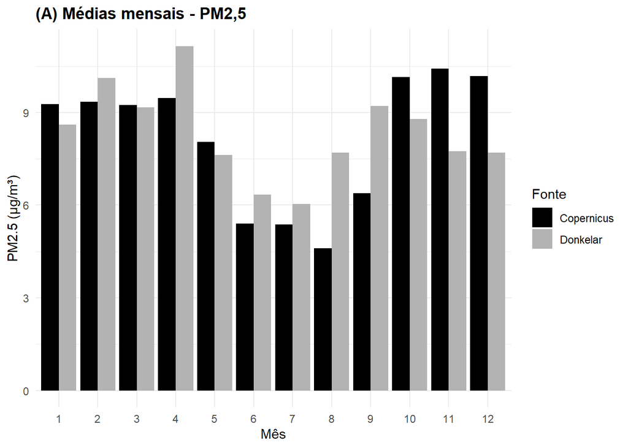

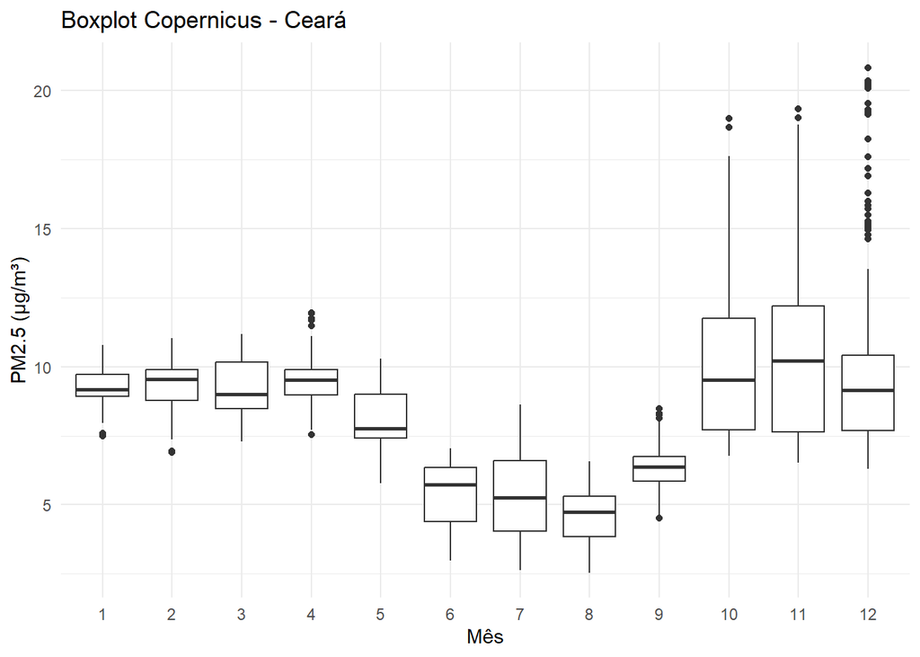

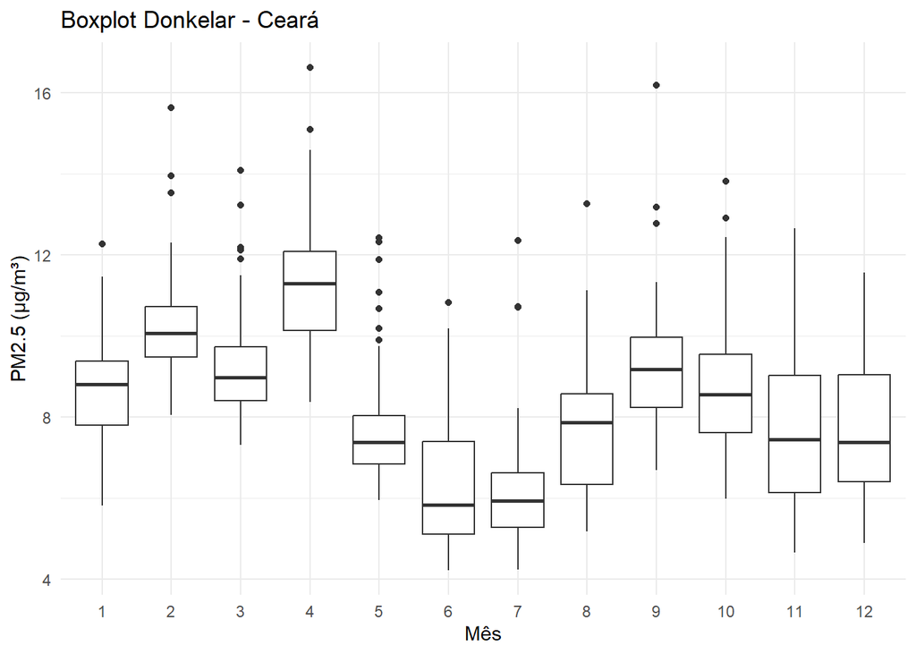

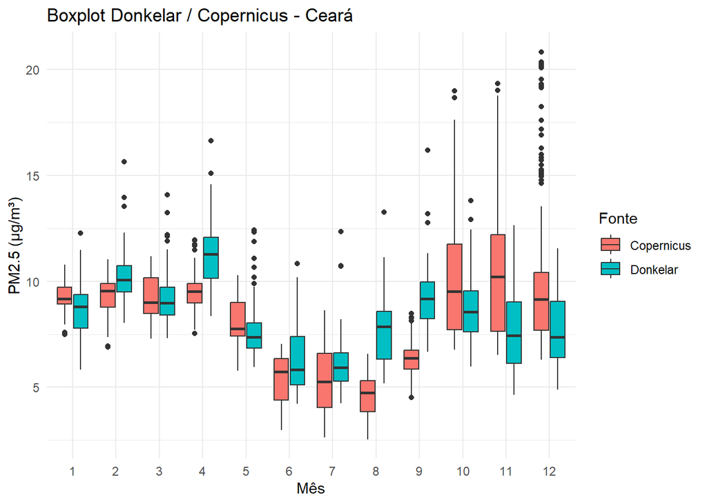

#### Os boxplots evidenciam que a variabilidade mensal nas concentrações de PM2.5 é mais pronunciada na base de dados Copernicus, o que pode estar relacionado à sua maior sensibilidade a eventos pontuais de poluição atmosférica. Já os dados de Donkelar apresentam menor dispersão, indicando uma possível suavização nos valores médios mensais.

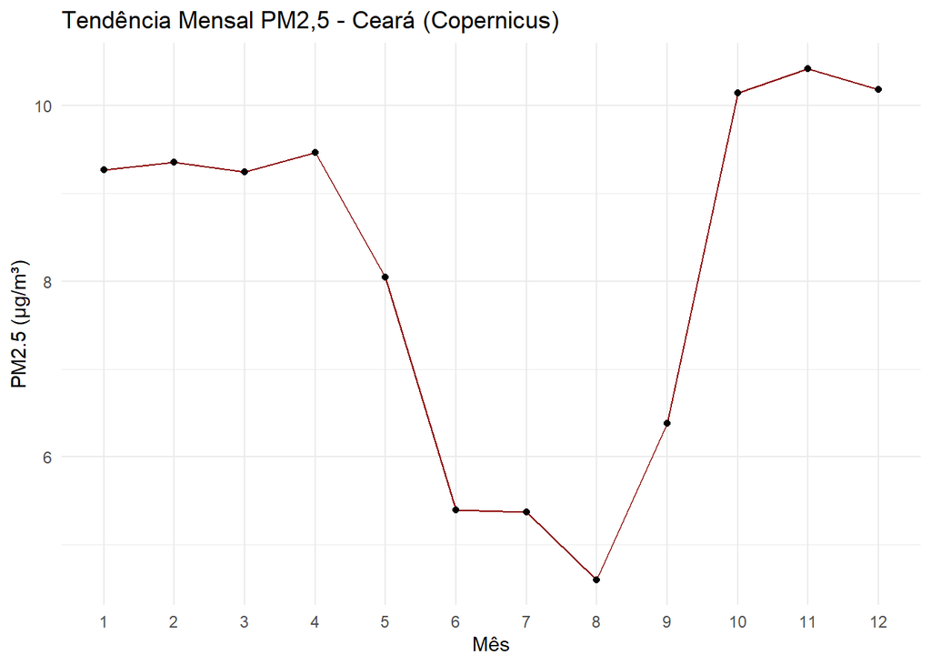

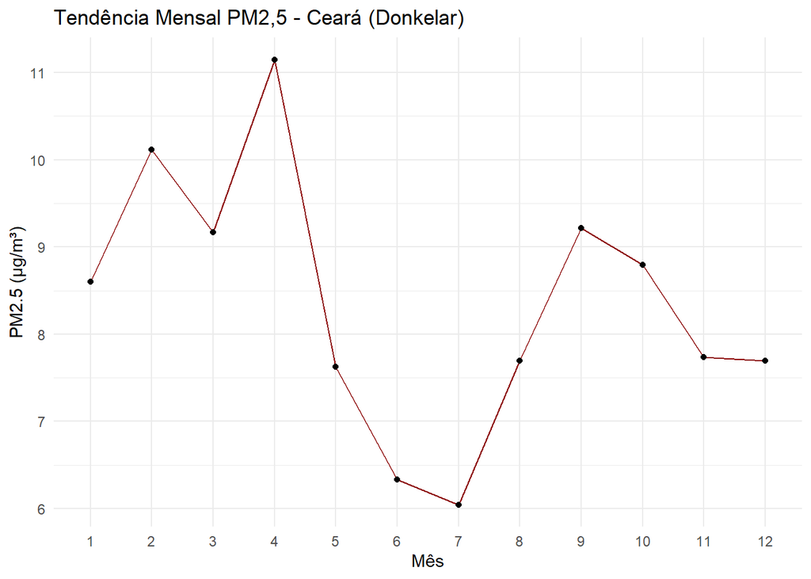

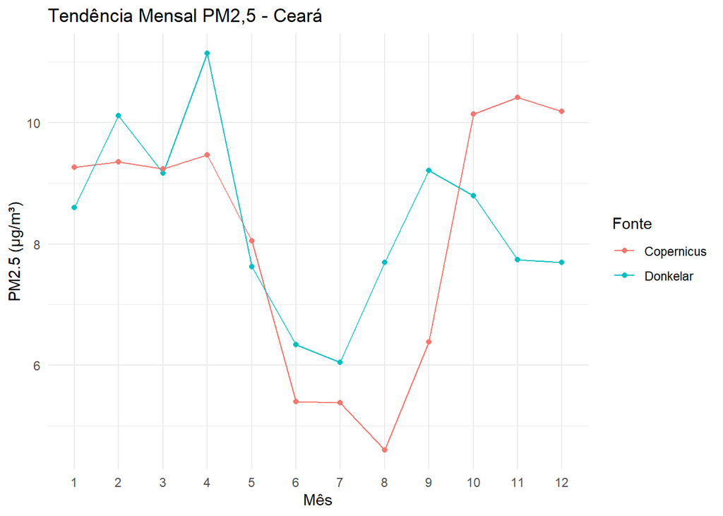

#### O gráfico de linhas demonstra taxas altas no começo do ano seguido de uma brusca queda a partir do mês de abril. Essa queda vai até agosto, onde ambas as fontes apresentam um crescimento. Já no mês de setembro as fontes se diferenciam, com Copernicus continuandoo em alto crescimento enquaanto Donkelar apresenta leve reduçao dos valores. Copernicus desacelera o crescimento a partir de outubro.

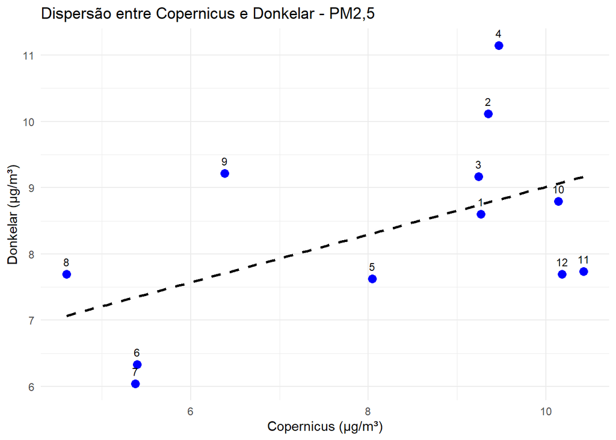

## Mapa - Fonte: Copernicus

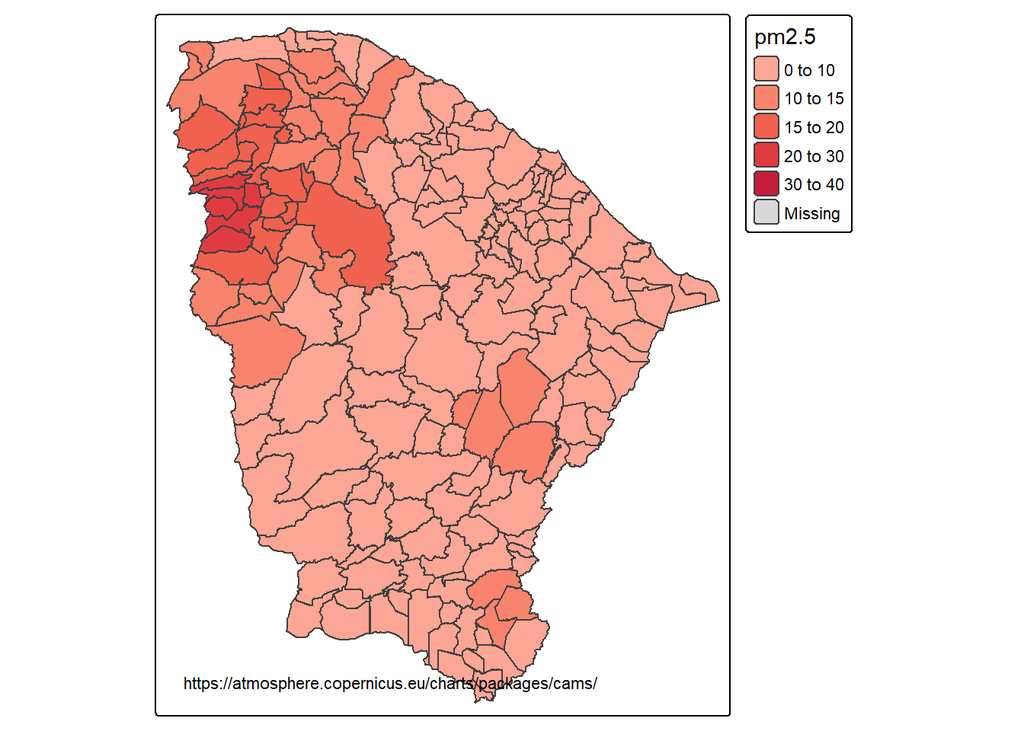

## Mapa - Fonte: Donkelar

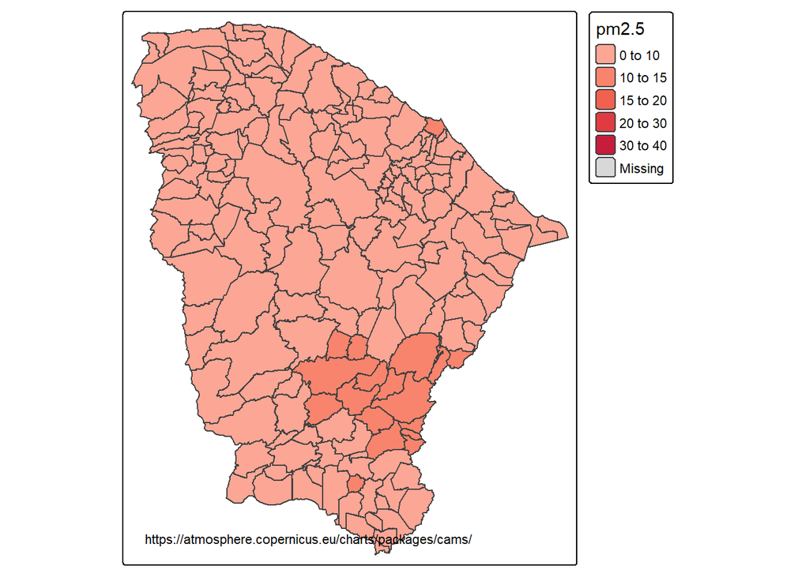